# Assess diversity of the PCV data set

Shaoqian Huang

2026-09-24

## Aims

The document aims to apply the proposed model-based assessment of diversity on the percentage cover value (PCV) data set and check if the model-based estimation of diversity is consistent with randomized Rao’s Q, which has been demonstrated that they are consistent in the simulation.

In order to simplify the modelling the process, I keep the species whose absence rate is lower than $55\%$, so there are 12 out of 296 species are left.

## Data Pro-Processing

### Read raw data

```r
tree <- read.tree("../data/example.tre")

trait <- read.csv(
  "../data/trait data.csv",
  stringsAsFactors = FALSE
)

my.sample <- read.csv(
  "../data/community data.csv",
  stringsAsFactors = FALSE
)
```

### Harmonize species names between tree and community data

```r
# Convert underscores in tree tip labels to periods to match the community data.
tree_species <- str_replace_all(
  tree$tip.label,
  "_",
  "."
)

community_species <- colnames(my.sample)

# Identify tree species whose names do not have a unique match in the
# community dataset.
unmatched_index <- which(
  !tree_species %in% community_species
)

# Manually correct known species-name mismatches.
tree_species[unmatched_index] <- c(
  "Astragalus.dasyanthus.exscapus",
  "Populus.alba...P..x.canescens",
  "Capsella.bursa.pastoris",
  "Festuca.rupicola.valesiaca",
  "Stipa.borysthenica.capillata"
)

tree$tip.label <- tree_species
```

### Filter community data by removing rare species

```r
# Keep species missing in less than rare_threshold of plots.
zero_threshold <- 0.55
zero_prop <- colMeans(
  my.sample == 0,
  na.rm = TRUE
)

# my.sample.filtered <- my.sample %>%
#   select(
#     where(~ TRUE)
#   )

# Apply the occurrence filter only to species columns.
species_columns <- colnames(my.sample)[-c(1, 2)]

species_to_keep <- species_columns[
  zero_prop[species_columns] <= zero_threshold
]

my.sample.filtered <- my.sample %>%
  select(
    all_of(colnames(my.sample)[1:2]),
    all_of(species_to_keep)
  )


# Species retained for the model.
selected_species <- colnames(
  my.sample.filtered
)[-c(1, 2)]

# The number if species retained for the model
p <- length(selected_species)
```

Species present more than 45% of all the plots are kept.

### Convert community data to long format

```r
yX <- reshape(
  my.sample.filtered,
  direction = "long",
  varying = selected_species,
  v.names = "y",
  timevar = "sp",
  times = selected_species
)

# Convert grouping variables to factors.
yX[c("sp", "Site", "Community", "id")] <-
  lapply(
    yX[c("sp", "Site", "Community", "id")],
    factor
  )

# Convert percentage cover to proportions.
yX$y <- yX$y / 100

# ordBeta requires values strictly between 0 and 1.
yX$y[yX$y >= 1] <- 0.9999
```

## Distance and Similarity Matrices

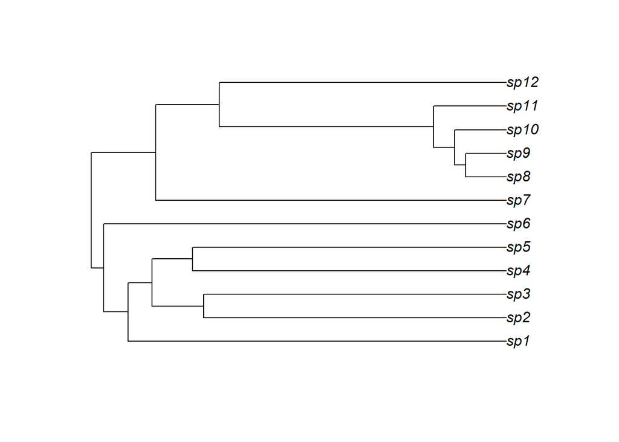

```r
# Keep only species present in the filtered community dataset.
subtree <- keep.tip(
  tree,
  selected_species
)
# Replace species labels
subtree_plot <- subtree
subtree_plot$tip.label <- paste0("sp", seq_along(subtree_plot$tip.label))

plot(subtree_plot)
```

```r
# Phylogenetic distance matrix.
# The order of species in DM_phy_func is the same as the order of species in subtree, and the order corresponds to sp1, sp2, sp3,...,sp12.
DM_phy_func <- cophenetic.phylo(subtree)


# Convert distance to a similarity-like matrix.
VC_phy_func <- max(DM_phy_func) - DM_phy_func


# Project the similarity matrix onto the centred subspace

J <- diag(p) -
  (1 / p) * matrix(1, p, p)


VC_phy_func_J <- J %*%
  VC_phy_func %*%
  J

V_J <- eigen(VC_phy_func_J)$vectors
D_J <- eigen(VC_phy_func_J)$values
```

The reason we are interested into $\boldsymbol{V}_J$ is that the column space of $\boldsymbol{V}_J$ strategically represents $\boldsymbol{R}^{p}$ as $\boldsymbol{1}^{\perp} \oplus \boldsymbol{1}$, where the former is the relative abundance space and latter is the total abundance space. This provides a way of studying relative abundance, which is abundance limited within space $\boldsymbol{1}^{\perp}$.

## Modelling and Modelling Diagnosis

```r
# e <- new.env()
# load("C:/Users/huang/OneDrive - UNSW/PhD Project/Model contrasts/Simulation/Simulation with wide settings/Code refactoring/Model-based assessment of PD and FD/Real application/Model/workspace_20260419.RData", envir = e)
#
# model <- e$fit_Model_5

model <- glmmTMB(
  y ~ sp +
    Community +
    sp:Community +
    rr(sp + 0 | id, 2),
  family = "ordbeta",
  REML = FALSE,
  data = yX
)
summary(model)
```

```
##  Family: ordbeta  ( logit )
## Formula:          y ~ sp + Community + sp:Community + rr(sp + 0 | id, 2)
## Data: yX
##
##      AIC      BIC   logLik deviance df.resid
##  -9642.8  -8827.0   4943.4  -9886.8     5806
##
## Random effects:
##
## Conditional model:
##  Groups Name                            Variance Std.Dev. Corr
##  id     spAsparagus.officinalis         0.005657 0.07521
##         spBerberis.vulgaris             0.020589 0.14349   0.39
##         spCalamagrostis.epigeios        0.060132 0.24522   0.71 -0.37
##         spCarex.liparicarpos            0.018303 0.13529  -0.95 -0.66 -0.45
##         spCeltis.occidentalis           0.001254 0.03542  -0.58 -0.98  0.16
##         spCrataegus.monogyna            1.668832 1.29183  -0.95 -0.65 -0.47
##         spEuphorbia.cyparissias         0.014139 0.11891   1.00  0.44  0.67
##         spFestuca.vaginata              0.079278 0.28156   0.81 -0.22  0.99
##         spLigustrum.vulgare             1.109640 1.05339  -0.14  0.86 -0.80
##         spPoa.angustifolia              0.014127 0.11886   0.99  0.28  0.79
##         spPopulus.alba...P..x.canescens 0.582456 0.76319   0.79 -0.25  0.99
##         spStipa.borysthenica.capillata  0.250902 0.50090   0.56  0.98 -0.19
##
##
##
##
##
##   0.80
##   1.00  0.80
##  -0.97 -0.62 -0.97
##  -0.59  0.01 -0.60  0.78
##  -0.18 -0.73 -0.17 -0.08 -0.69
##  -0.91 -0.48 -0.91  0.98  0.87 -0.25
##  -0.56  0.04 -0.57  0.76  1.00 -0.71  0.86
##  -0.79 -1.00 -0.78  0.61 -0.03  0.74  0.46 -0.06
## Number of obs: 5928, groups:  id, 494
##
## Dispersion parameter for ordbeta family (): 10.8
##
```

[output cut: 182 more lines]

```
## spPopulus.alba...P..x.canescens:CommunitySE  < 2e-16 ***
## spStipa.borysthenica.capillata:CommunitySE  2.98e-13 ***
## spBerberis.vulgaris:CommunitySF             0.000440 ***
## spCalamagrostis.epigeios:CommunitySF        0.099593 .
## spCarex.liparicarpos:CommunitySF            0.097976 .
## spCeltis.occidentalis:CommunitySF           0.308151
## spCrataegus.monogyna:CommunitySF            3.00e-05 ***
## spEuphorbia.cyparissias:CommunitySF         0.000244 ***
## spFestuca.vaginata:CommunitySF              0.412801
## spLigustrum.vulgare:CommunitySF             0.310904
## spPoa.angustifolia:CommunitySF              0.000162 ***
## spPopulus.alba...P..x.canescens:CommunitySF  < 2e-16 ***
## spStipa.borysthenica.capillata:CommunitySF   < 2e-16 ***
## ---
## Signif. codes:  0 '***' 0.001 '**' 0.01 '*' 0.05 '.' 0.1 ' ' 1
```

## Diversity Assessment

### Extract fixed and random effects

```r
## Estimates of fixed effects, eta_T
eta_T_hat <- predict(model,
                   type = "link",
                   re.form = NA)

# Arrange eta_T_hat into a matrix
eta_T_hat <- matrix(
  as.numeric(eta_T_hat),
  ncol = p,
  byrow = FALSE
)

# Estimates of row centered fixed effects, eta_B
eta_B_hat <- eta_T_hat %*% J

##  Estimates of conditional random effects on y
RR <- simulate_random_effects(model = model, uncertainty = TRUE)
```

### Is $\hat{\boldsymbol{\mu}}_B^{\top}\boldsymbol{D}\hat{\boldsymbol{\mu}}_B$ consistent with randomized Rao’s Q?

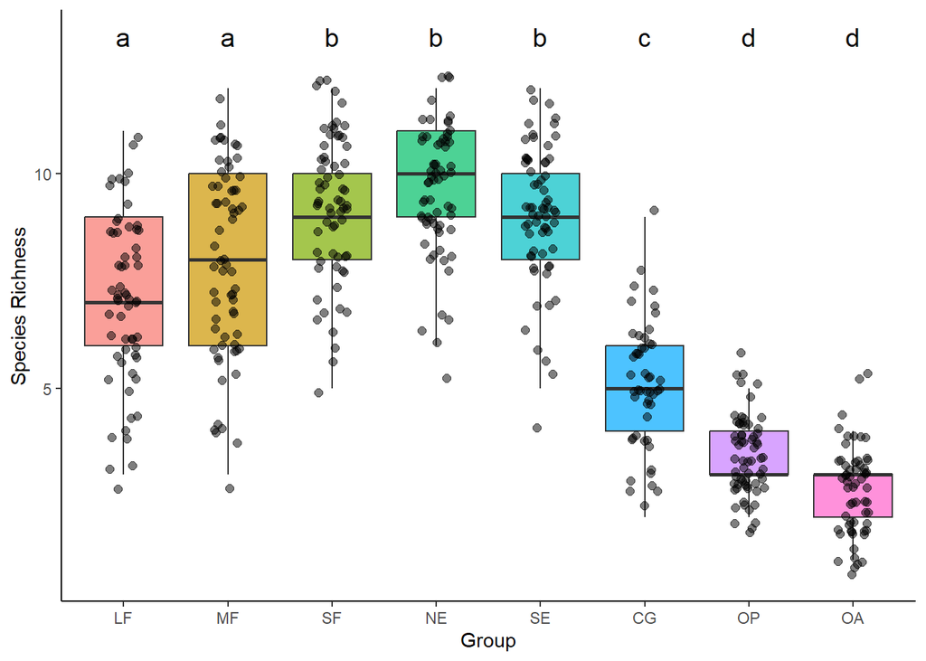

```r
abundance <- as.matrix(my.sample.filtered[
  ,
  colnames(DM_phy_func),
  drop = FALSE
])
## Species richness
SR <- specnumber(abundance)
SR_data <- data.frame(
  group = my.sample.filtered$Community,
  value = SR
)
fig_SR <- Boxplot(
  data = SR_data,
  group_levels = c(
      "LF",
      "MF",
      "SF",
      "NE",
      "SE",
      "CG",
      "OP",
      "OA"
    ),
    ylab = "Species Richness")
fig_SR
```

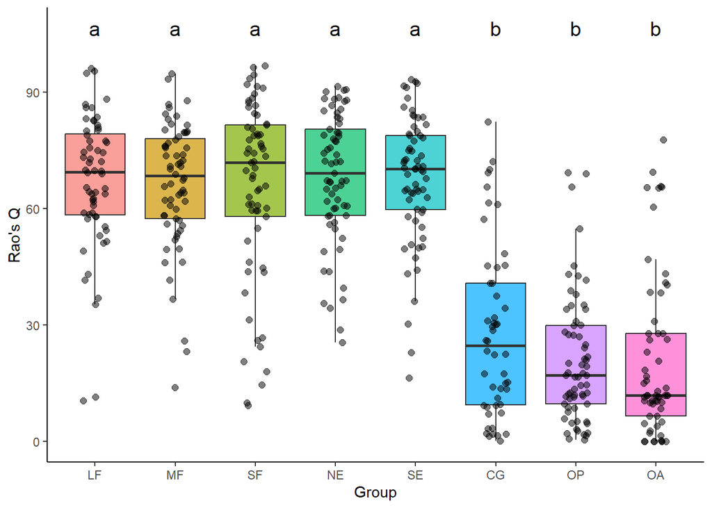

```r
## Rao's Q
RaosQ <- RaoQ(my.sample= abundance, DM = DM_phy_func)
RaosQ_data <- data.frame(
  group = my.sample.filtered$Community,
  value = RaosQ
)
fig_raosQ <- Boxplot(
  data = RaosQ_data,
  group_levels = c(
      "LF",
      "MF",
      "SF",
      "NE",
      "SE",
      "CG",
      "OP",
      "OA"
    ),
    ylab = "Rao's Q")
fig_raosQ
```

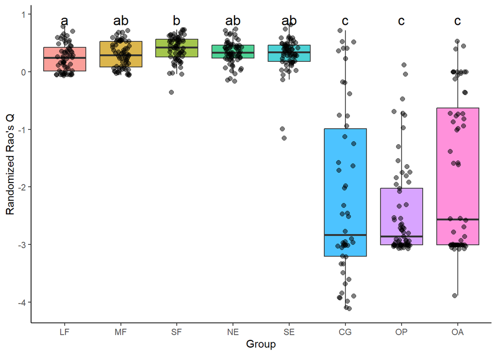

```r
## Randomized Rao's Q diversity for reference
# Ensure that the abundance matrix has the same species and ordering as the
# phylogenetic distance matrix.
# Calculate SES of Rao's Q using tip randomization.
RaosQ_rand <- randomization(
  abundance = abundance,
  DM_phy_func = DM_phy_func
)

# Combine randomized Rao's Q values with community groups.
RaosQ_rand_data <- data.frame(
  group = my.sample.filtered$Community,
  value = RaosQ_rand
)

fig1 <- Boxplot(data = RaosQ_rand_data,
                group_levels = c(
      "LF",
      "MF",
      "SF",
      "NE",
      "SE",
      "CG",
      "OP",
      "OA"
    ),
    ylab = "Randomized Rao's Q")
fig1
```

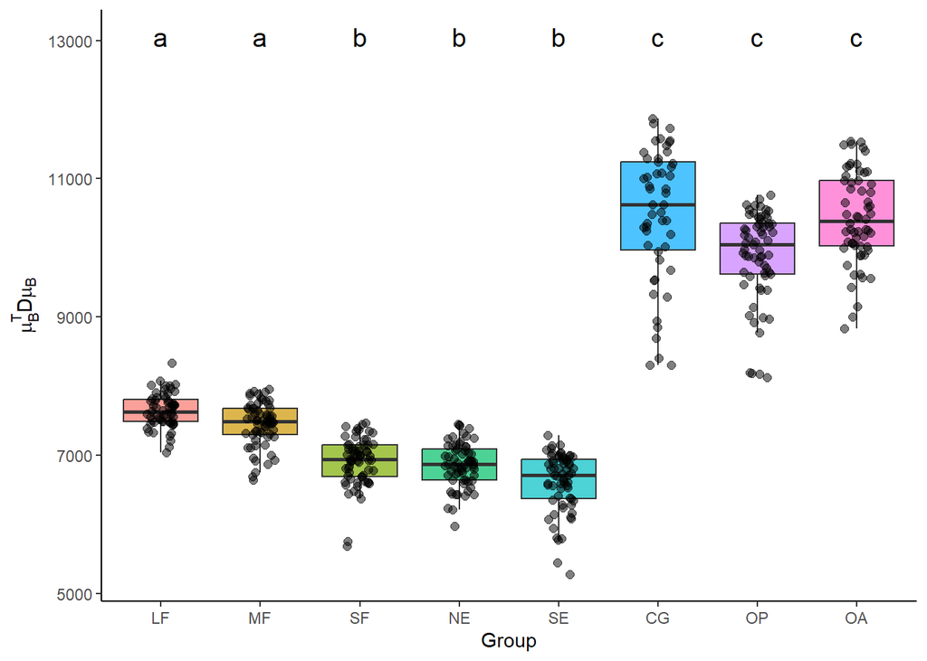

```r
## Produce boxplot for model-based diversity in each com
# Mean abundance scale
mu_eta_B_u_hat <- expit(eta_B_hat + RR %*% J)

p_mu <- make_div_boxplot(
  mu_eta_B_u_hat,
  ylab = expression(mu[B]^T * D * mu[B])
)
p_mu
```

We plot the boxplots plots for speciess richness and rao’s Q to know our data sets.The boxplot describing species richness shows that species increases continously along gradients LF, MF, SF, NE, and then drops continuously through gradients SE, CG, OP, and OA. The boxplot for rao’s Q shows diversity keeps the same level along gradients LF, MF, SF, NE, and SE, and then drops and keeps the same along gradients CG, OP, OA.

We boxplot randomized Rao’s Q as the expectation. It tells us the diversity is supposed to retain at a high level along LF, MF, SF, NE, SE, and then drops sharply at CG and keep the same level along CG, OP and OA.

The fourth boxplot shows the estimated diversity based on $\hat{\boldsymbol{\mu}}_B^{\top}\boldsymbol{D}\hat{\boldsymbol{\mu}}$, which shows us an exactly reversed trend with Randomized rao’s Q.

## Conclusion

1. The boxplot of randomized Rao’s Q can be as our expectation not only because I have demonstrated it through simulated beta and Bernoulli data, but also the its boxplot is consistent with the boxplots of species richness rao’s Q.
2. The boxplot shows that the proposed diversity estimator $\hat{\boldsymbol{\mu}}_B^{\top}\boldsymbol{D}\hat{\boldsymbol{\mu}}$ can’t get consistent results with randomized Rao’s Q. The question that if the relative abundance is estimated properly in the percentage cover data set is worthwhile to explore.